# Bellabeat Case Study

Hannah Chapman

2023-01-15

## Overview

Bellabeat is a fictional manufacturer of high-tech wellness products for women- including a wellness app, 2 forms of digital activity tracking devices, a water bottle that tracks daily water intake, and a personalized wellness membership program.

The marketing analytics team was tasked with analyzing general smart device usage trends and using these to inform Bellabeat marketing strategy.

## Business Task

The key questions I looked to answer in this analysis were:

- What are some trends in smart device usage?
- How could these trends apply to Bellabeat customers?
- How could these trends help influence Bellabeat marketing strategy?

## Dataset

The initial dataset that I was provided was [FitBit Fitness Tracker Data](https://www.kaggle.com/datasets/arashnic/fitbit), which is a dataset in the Public Domain that was made available through Mobius.

This dataset includes personal tracker data from thirty FitBit users, including physical activity, heart rate, daily activity, steps, and sleep monitoring.

The limitations of this dataset are that it is only from 30 participants, so any trends may not be representative of the Bellabeat target market. The participants were also selected through Amazon Mechanical Turk, which is a 3rd party data collection source.

To offset these potential limitations, the results of this data were analyzed alongside previous research that was already conducted on smart device wearers. The studies that were looked at include “How Do We Engage With Activity Trackers? A Longitudinal Study of Habito”, conducted in 2015 by Gouveia, Rúben & Karapanos and Evangelos & Hassenzahl, Marc, “Determinants for Sustained Use of an Activity Tracker: Observational Study”, conducted in 2017 by Hermsen S, Moons J, Kerkhof P, Wiekens C and De Groot M., and “Consumer-Based Wearable Activity Trackers Increase Physical Activity Participation: Systematic Review and Meta-Analysis” conducted in 2019 by Brickwood K, Watson G, O’Brien J and Williams A.

## Cleaning

An initial review of the dataset was done in Excel to get a better understanding of the type of data I was working with. The dataset included 18 separate CSVs, of which 14 contained data on each participant’s steps, intensities, calories, and heart rate per each second, minute, hour, and day of the 1 month tracking period.

Upon reviewing the CSVs, one sheet had a combined total for steps, intensities and calories burned per day for each participant. This was confirmed by adding together the data for the hourly tracking and comparing against the daily tracking in Excel. Since this sheet was a merged format of the prior separate sheets, this sheet was used for my analysis.

2 of the CSVs had extremely limited and incomplete data on participants’ sleep and weight logs, so were analyzed separately from the combined participant data.

The merged CSV was uploaded to RStudio Cloud for further cleaning and analysis. The following packages were installed:

```r
install.packages("tidyverse")
install.packages("lubridate")
```

Then the prior packages were loaded for use:

```r
library(tidyverse)
library(lubridate)
```

The CSV was stored as a dataframe:

```r
data.df <- read_csv("dailyActivity_merged.csv")
```

And then I reviewed the structure of the dataframe to check for discrepancies:

```r
str(data.df)
```

```
## spc_tbl_ [940 × 15] (S3: spec_tbl_df/tbl_df/tbl/data.frame)
##  $ Id                      : num [1:940] 1.5e+09 1.5e+09 1.5e+09 1.5e+09 1.5e+09 ...
##  $ ActivityDate            : chr [1:940] "4/12/2016" "4/13/2016" "4/14/2016" "4/15/2016" ...
##  $ TotalSteps              : num [1:940] 13162 10735 10460 9762 12669 ...
##  $ TotalDistance           : num [1:940] 8.5 6.97 6.74 6.28 8.16 ...
##  $ TrackerDistance         : num [1:940] 8.5 6.97 6.74 6.28 8.16 ...
##  $ LoggedActivitiesDistance: num [1:940] 0 0 0 0 0 0 0 0 0 0 ...
##  $ VeryActiveDistance      : num [1:940] 1.88 1.57 2.44 2.14 2.71 ...
##  $ ModeratelyActiveDistance: num [1:940] 0.55 0.69 0.4 1.26 0.41 ...
##  $ LightActiveDistance     : num [1:940] 6.06 4.71 3.91 2.83 5.04 ...
##  $ SedentaryActiveDistance : num [1:940] 0 0 0 0 0 0 0 0 0 0 ...
##  $ VeryActiveMinutes       : num [1:940] 25 21 30 29 36 38 42 50 28 19 ...
##  $ FairlyActiveMinutes     : num [1:940] 13 19 11 34 10 20 16 31 12 8 ...
##  $ LightlyActiveMinutes    : num [1:940] 328 217 181 209 221 164 233 264 205 211 ...
##  $ SedentaryMinutes        : num [1:940] 728 776 1218 726 773 ...
##  $ Calories                : num [1:940] 1985 1797 1776 1745 1863 ...
##  - attr(*, "spec")=
##   .. cols(
##   ..   Id = col_double(),
##   ..   ActivityDate = col_character(),
##   ..   TotalSteps = col_double(),
##   ..   TotalDistance = col_double(),
##   ..   TrackerDistance = col_double(),
##   ..   LoggedActivitiesDistance = col_double(),
##   ..   VeryActiveDistance = col_double(),
##   ..   ModeratelyActiveDistance = col_double(),
##   ..   LightActiveDistance = col_double(),
##   ..   SedentaryActiveDistance = col_double(),
##   ..   VeryActiveMinutes = col_double(),
##   ..   FairlyActiveMinutes = col_double(),
##   ..   LightlyActiveMinutes = col_double(),
##   ..   SedentaryMinutes = col_double(),
##   ..   Calories = col_double()
##   .. )
##  - attr(*, "problems")=<externalptr>
```

The ActivityDate field was read as a string rather than a date datatype so I converted it:

```r
data.df$ActivityDate <- mdy(data.df$ActivityDate)
```

A review of the data from here showed that each column had the correct datatype and appropriate values for the corresponding trait being looked at, so I moved on to my analysis.

## Analysis

### Summary Statistics

The two main variables tracked in the complete dataset were the number of steps participants took and the number of calories they were calculated to have burned.

Summary statistics were calculated for steps taken and calories burned per day, and can be viewed in the summarized table.

```r
summarized <- data.df %>%
  group_by(ActivityDate) %>%
  summarize(min_steps = min(TotalSteps), max_steps = max(TotalSteps), avg_steps = mean(TotalSteps),
            med_steps = median(TotalSteps),total_steps = sum(TotalSteps),min_cals = min(Calories), max_cals = max(Calories),
            avg_cals = mean(Calories), med_cals = median(Calories),total_cals = sum(Calories))

summarized
```

```
## # A tibble: 31 × 11
##    ActivityDate min_st…¹ max_s…² avg_s…³ med_s…⁴ total…⁵ min_c…⁶ max_c…⁷ avg_c…⁸
##    <date>          <dbl>   <dbl>   <dbl>   <dbl>   <dbl>   <dbl>   <dbl>   <dbl>
##  1 2016-04-12          0   23186   8237.   8163   271816    1432    3921   2391.
##  2 2016-04-13          0   16433   7199.   7007   237558    1411    4079   2287.
##  3 2016-04-14          0   21129   7744.   7910   255538    1431    4163   2356.
##  4 2016-04-15        980   20669   7534.   7198   248617    1344    4005   2355.
##  5 2016-04-16          0   29326   8679.   7097   277733    1373    4547   2393.
##  6 2016-04-17          0   18827   6409.   6186.  205096    1214    4552   2231.
##  7 2016-04-18          0   17076   7897.   8004.  252703    1419    4157   2333.
##  8 2016-04-19          0   18785   8049.   7830.  257557    1356    4092   2359.
##  9 2016-04-20          0   19948   8163.   8562.  261215    1349    3787   2395.
## 10 2016-04-21          0   19542   8244.   8858   263795    1370    4900   2422.
## # … with 21 more rows, 2 more variables: med_cals <dbl>, total_cals <dbl>, and
## #   abbreviated variable names ¹min_steps, ²max_steps, ³avg_steps, ⁴med_steps,
## #   ⁵total_steps, ⁶min_cals, ⁷max_cals, ⁸avg_cals
```

I also calculated overall summary statistics for steps taken and calories burned as well.

```r
summarized_all <- data.df %>%
  summarize(min_steps = min(TotalSteps), max_steps = max(TotalSteps), avg_steps = mean(TotalSteps),
            med_steps = median(TotalSteps),total_steps = sum(TotalSteps),min_cals = min(Calories), max_cals = max(Calories),
            avg_cals = mean(Calories), med_cals = median(Calories),total_cals = sum(Calories))

summarized_all
```

```
## # A tibble: 1 × 10
##   min_steps max_steps avg_steps med_st…¹ total…² min_c…³ max_c…⁴ avg_c…⁵ med_c…⁶
##       <dbl>     <dbl>     <dbl>    <dbl>   <dbl>   <dbl>   <dbl>   <dbl>   <dbl>
## 1         0     36019     7638.    7406. 7179636       0    4900   2304.    2134
## # … with 1 more variable: total_cals <dbl>, and abbreviated variable names
## #   ¹med_steps, ²total_steps, ³min_cals, ⁴max_cals, ⁵avg_cals, ⁶med_cals
```

The average steps taken on day 1 of the study was approximately 8236, while the average steps taken on the last day of the study was approximately 3482.

The average calories burned on day 1 was 2390, while the average calories burned on the final day was 1139.

### Trends

To better understand the trends for steps taken and calories burned over time, I plotted each on a scatterplot.

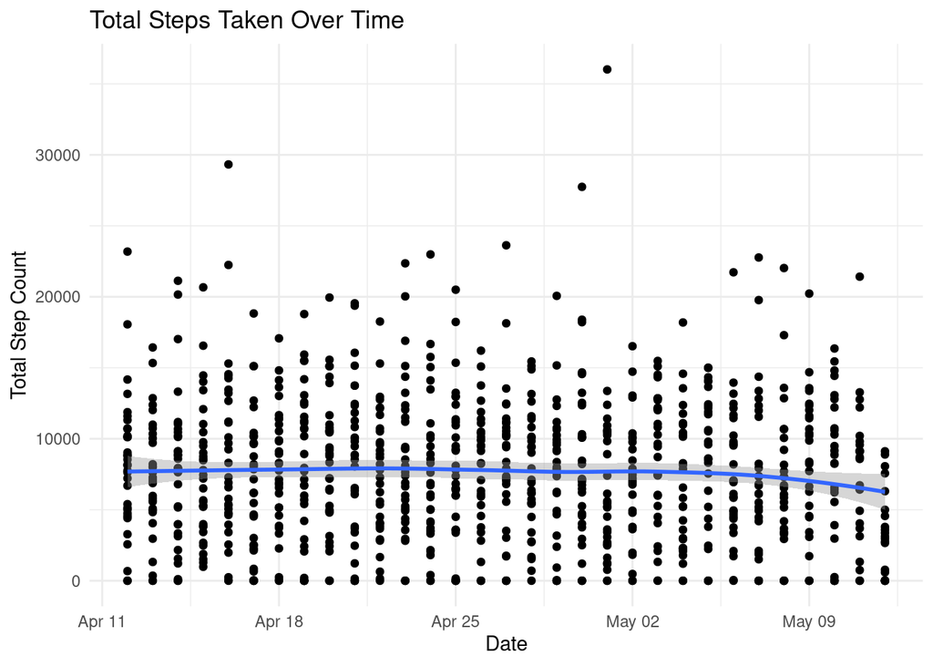

```r
totalsteps_vis <- ggplot(data=data.df, aes(x=ActivityDate, y=TotalSteps)) + geom_point() + geom_smooth() +
  xlab("Date") +
  ylab("Total Step Count") +
  labs(title = "Total Steps Taken Over Time") +
  theme_minimal()

totalsteps_vis
```

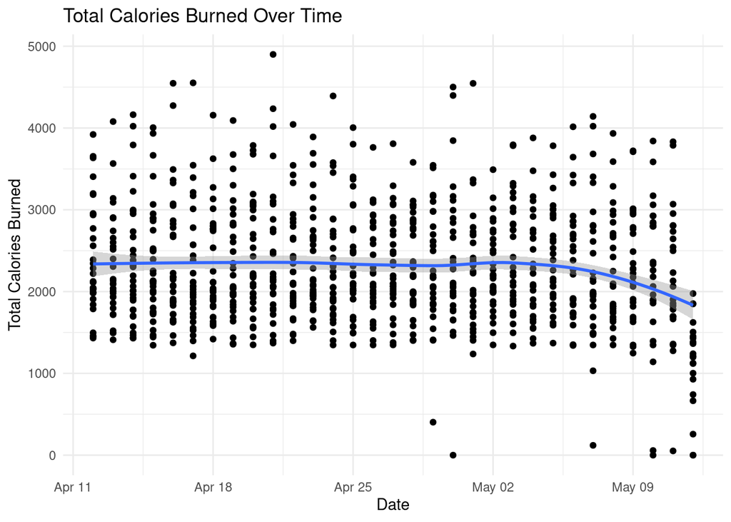

```r
totalcals_vis <- ggplot(data=data.df, aes(x=ActivityDate, y=Calories)) + geom_point() + geom_smooth() +
  xlab("Date") +
  ylab("Total Calories Burned") +
  labs(title = "Total Calories Burned Over Time") +
  theme_minimal()

totalcals_vis
```

These results align closely with insights from other analyses as well. The study “Determinants for Sustained Use of an Activity Tracker: Observational Study” tracked Fitbit Zip usage for 711 participants in France. They found a slow exponential decay for activity tracker usage, with 73.9% still tracking after 100 days, and only 16% tracking after 320 days.

However, the decrease in usage does not necessarily mean that activity trackers have no positive effect.

I noticed some outliers that were potentially dragging down the overall average, so I plotted the median number of steps taken and calories burned as well.

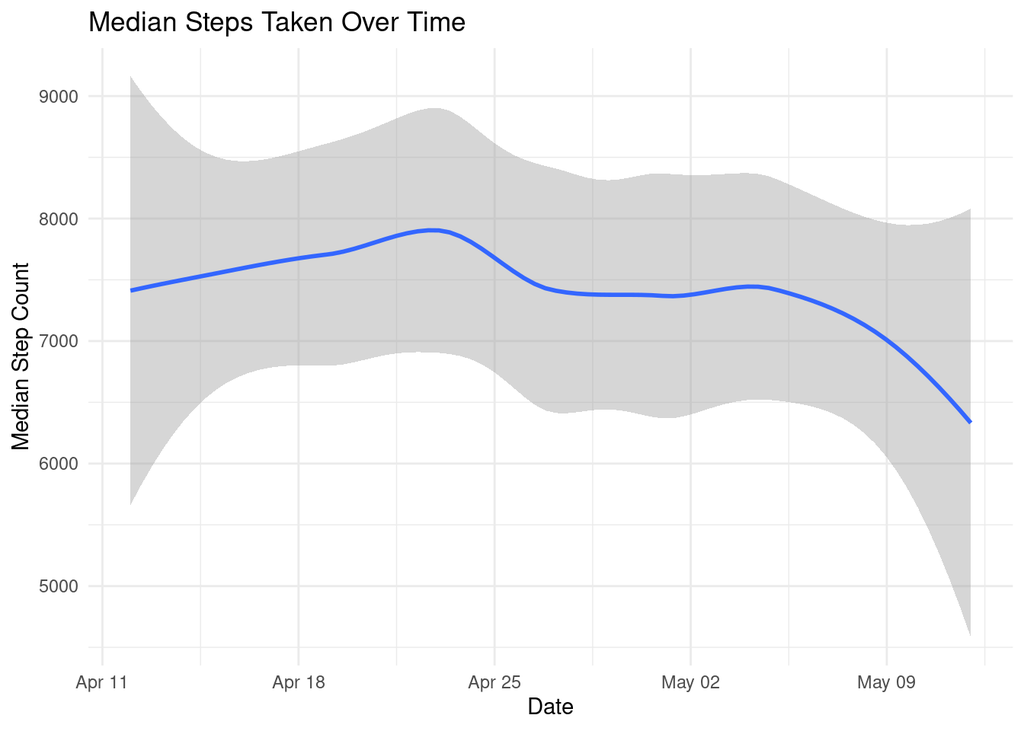

```r
medsteps_vis <- ggplot(data = summarized) + geom_smooth(mapping = aes(x=ActivityDate, y=med_steps)) +
  xlab("Date") +
  ylab("Median Step Count") +
  labs(title = "Median Steps Taken Over Time") +
  theme_minimal()

medsteps_vis
```

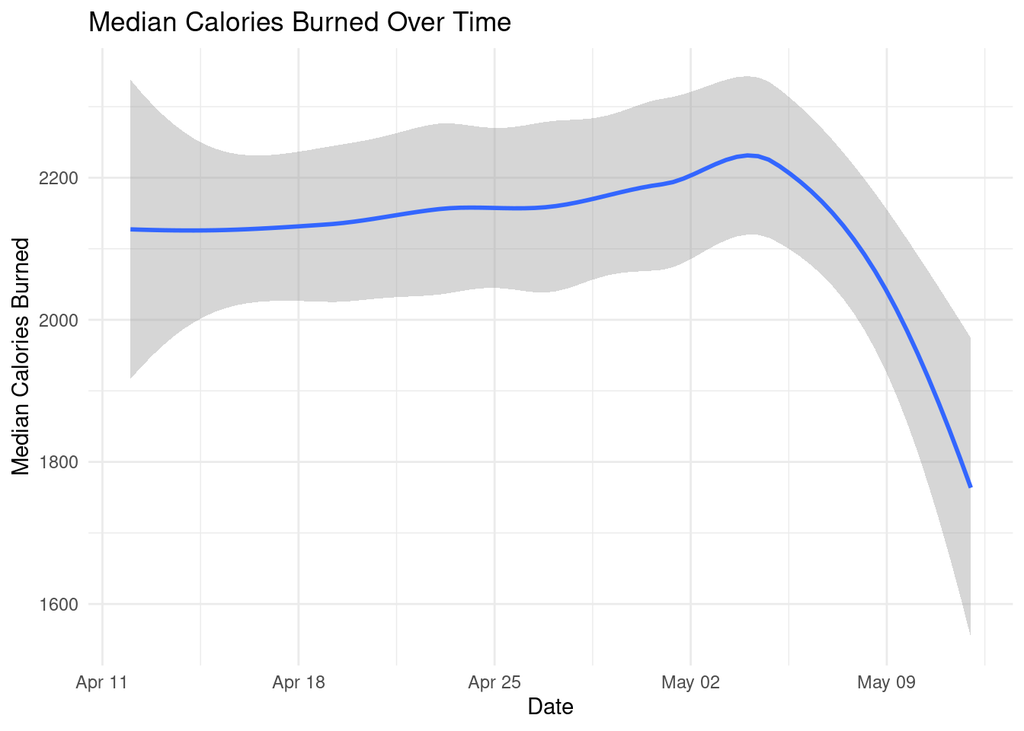

```r
medcals_vis <- ggplot(data = summarized) + geom_smooth(mapping = aes(x=ActivityDate, y=med_cals)) +
  xlab("Date") +
  ylab("Median Calories Burned") +
  labs(title = "Median Calories Burned Over Time") +
  theme_minimal()

medcals_vis
```

These close-ups of the trend lines for median steps taken and median calories burned show a slight increase in steps taken during the first week and a half of tracking, and a slight increase in calories burned during the first 3 weeks of tracking.

These trends align with what I saw in another research analysis as well. The article “Consumer-Based Wearable Activity Trackers Increase Physical Activity Participation: Systematic Review and Meta-Analysis” reviewed 28 randomized controlled trials that studied the use of consumer-based wearable activity trackers and found that “short-term interventions utilizing a consumer-based wearable activity tracker generally resulted in increased physical activity participation” (Brickwood K, Watson G, O’Brien J, Williams A, 2019)

## Recommendations

### Focus Marketing Content on Improvements in Physical Activity

Prior research also indicates that using a smart device for physical activity tracking can lead to a short-term increase in physical activity.

We can likely assume that Bellabeat users will follow a similar pattern - utilizing the trackers more initially and seeing an increase in the number of steps taken and calories burned when they start to track.

Marketing content for Bellabeat’s tracking devices should thus focus on the potential physical improvements users could see when starting to track their activity and how this would benefit their health.

### Target Marketing to Ages 36-55

There is also a specific subset of the population that would be more likely to engage with Bellabeat’s products. The study “Determinants for Sustained Use of an Activity Tracker: Observational Study” found that one of the greatest indicators of continued physical activity tracker usage was age.

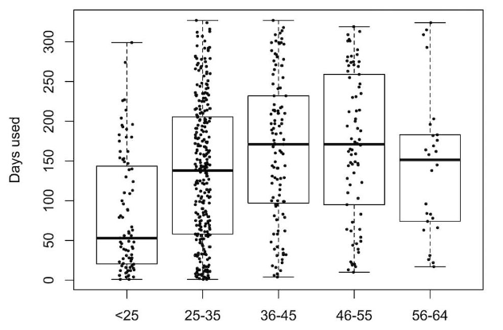

Figure 5 - Hermsen S, Moons J, Kerkhof P, Wiekens C and De Groot M., 2017

Participants who were aged 36-55 showed the longest usage of their activity trackers, even when all other factors were accounted for (including gender). Thus, this subsection of the population should be targeted for marketing because the longer Bellabeat can keep users engaged, the more profit they can make from each user. It will cost less over time to have repeat customers for their current products than to try and market and engage an entirely new user.

### Tarket Marketing to “Contemplation” and “Preparation” Stages Using Keywords

Finally, there is a specific level of readiness associated with those who maintain usage of these types of tracking devices. The study “How Do We Engage With Activity Trackers? A Longitudinal Study of Habito” found that those who were in the “Contemplation” and “Preparation” stages of readiness had much higher adoption rates of the physical activity tracking application being looked at. The “Contemplation” phase includes not being active but planning to become active soon, while the “Preparation” phase is described as trying but not yet regularly being active.

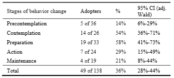

Table 1 - Gouveia, Rúben & Karapanos and Evangelos & Hassenzahl, Marc, 2015

Marketing should thus be targeted towards the kinds of potential users who may be in the “Contemplation” or “Preparation” stages of readiness for tracking in order to see long-term usage. There are likely certain keywords these potential users are searching online as they are thinking about taking the step towards becoming physically active - testing and capitalizing on these keywords will lead to long-term success.